# EDA - miliarderzy (2023)

Szymon Haładyna

2026-01-15

# Pakiety, których będę używał

```r
library("tidyverse")
library("dplyr")
library("ggplot2")
library("treemapify")
library("countrycode")
```

# Wprowadzenie do analizy

Majątek najbogatszych ludzi świata to temat, który budzi wiele różnych emocji. Od podziwu dla ludzkiej przedsiębiorczości i innowacyjności, po dyskusje na temat nierówności społecznych. Gdyby razem zebrać pieniądze 10 najbogatszych ludzi świata, otrzymalibyśmy kwotę przewyższającą PKB wielu krajów.

### O zbiorze danych

W tym projekcie skupie się na analizie zbiór danych **“Billionaires Statistics Dataset”**, który zawiera szczegółowe informacje na temat najbogatszych ludzi świata. W zestawie danych znajdują się zmienne opisujące m.in.: wartość majątku, dane demograficzne, lokalizację, źródło majątku. Jak nazwa wskazuje w zbiorze mamy wszystkich ludzi, których majątek wyniósł 1mld dolarów lub więcej na rok **2023**.

### Cel projektu

Celem tej pracy jest przeprowadzeni EDA aby zrozumieć strukturę światowego bogactwa.

W ramach analizy postaram się odpowiedzieć na pytania badawcze dotyczące:

1. Czy wiek i płeć różnicują grupę najbogatszych?
2. Gdzie na świecie koncentracja kapitału jest największa?
3. Jak miliarderzy zdobywają swój majątek?
4. Jakie branże tworzą miliarderów?

Z danych wybieram `rank`, `personName`, `age`, `finalWorth`, `category`, `country`, `gender`, `selfMade`, `gdp_country`, które będą potrzebne do dalszej analizy.

```r
dane <- read.csv("Billionaires.csv")
dane <- dane %>%
  select(rank, personName, age, finalWorth, category, country, gender, selfMade, gdp_country)
head(dane)
```

```
##   rank               personName age finalWorth              category
## 1    1 Bernard Arnault & family  74     211000      Fashion & Retail
## 2    2                Elon Musk  51     180000            Automotive
## 3    3               Jeff Bezos  59     114000            Technology
## 4    4            Larry Ellison  78     107000            Technology
## 5    5           Warren Buffett  92     106000 Finance & Investments
## 6    6               Bill Gates  67     104000            Technology
##         country gender selfMade          gdp_country
## 1        France      M    FALSE  $2,715,518,274,227
## 2 United States      M     TRUE $21,427,700,000,000
## 3 United States      M     TRUE $21,427,700,000,000
## 4 United States      M     TRUE $21,427,700,000,000
## 5 United States      M     TRUE $21,427,700,000,000
## 6 United States      M     TRUE $21,427,700,000,000
```

```r
tail(dane)
```

```
##      rank             personName age finalWorth        category       country
## 2635 2540  Yi Xianzhong & family  63       1000      Healthcare         China
## 2636 2540                Yu Rong  51       1000      Healthcare         China
## 2637 2540 Richard Yuengling, Jr.  80       1000 Food & Beverage United States
## 2638 2540          Zhang Gongyun  60       1000   Manufacturing         China
## 2639 2540 Zhang Guiping & family  71       1000     Real Estate         China
## 2640 2540            Inigo Zobel  66       1000     Diversified   Philippines
##      gender selfMade          gdp_country
## 2635      M     TRUE $19,910,000,000,000
## 2636      M     TRUE $19,910,000,000,000
## 2637      M    FALSE $21,427,700,000,000
## 2638      M     TRUE $19,910,000,000,000
## 2639      M     TRUE $19,910,000,000,000
## 2640      M    FALSE    $376,795,508,680
```

### Struktura danych - `str()`

```r
str(dane)
```

```
## 'data.frame':    2640 obs. of  9 variables:
##  $ rank       : int  1 2 3 4 5 6 7 8 9 10 ...
##  $ personName : chr  "Bernard Arnault & family" "Elon Musk" "Jeff Bezos" "Larry Ellison" ...
##  $ age        : int  74 51 59 78 92 67 81 83 65 67 ...
##  $ finalWorth : int  211000 180000 114000 107000 106000 104000 94500 93000 83400 80700 ...
##  $ category   : chr  "Fashion & Retail" "Automotive" "Technology" "Technology" ...
##  $ country    : chr  "France" "United States" "United States" "United States" ...
##  $ gender     : chr  "M" "M" "M" "M" ...
##  $ selfMade   : logi  FALSE TRUE TRUE TRUE TRUE TRUE ...
##  $ gdp_country: chr  "$2,715,518,274,227 " "$21,427,700,000,000 " "$21,427,700,000,000 " "$21,427,700,000,000 " ...
```

Po wstępnej analize można zauważyć, ze `gdp_country`jest przedstawiony jako ciąg znaków i w dodatku zawiera przecinki i znak $. Jescze dodatkowo trzeba zmienić nazwy niektórych kolumn, np. finalworth nie jest zbytnio intuicyjne, lepsze będzie NetworthMln. `rank` nie jest unikalny, ale nie jestem jeszcze pewien, czy będzie to przeszkodą.

### Obróbka danych

```r
dane <- dane %>%
  select(Rank = rank, Name = personName, Age = age, NetWorthMln = finalWorth, Category = category, Country = country, Gender = gender, GdpCountry = gdp_country, SelfMade = selfMade) %>%
  mutate(GdpCountryMld = parse_number(GdpCountry)/1000000000, NetWorthMld = NetWorthMln/1000)

colSums(is.na(dane))
```

```
##          Rank          Name           Age   NetWorthMln      Category
##             0             0            65             0             0
##       Country        Gender    GdpCountry      SelfMade GdpCountryMld
##             0             0             0             0           164
##   NetWorthMld
##             0
```

Dane zostały uporządkowane i wartości w kolumnach `GdpCountry` oraz `NetWorthMln` sprowadziłem do miliardów. Kolumny `Age` i `GdpCountryMld` ma braki, ale na razie nie będę usuwał wierszy z tymi brakami, żeby nie tracić innych potrzebnych danych na temat miliarderów.

# Analiza

Po uporządkowaniu danych przejdźmy do głównej części analizy.

### Czy rzeczywiście największy majątek jest gromadzony w starszym wieku?

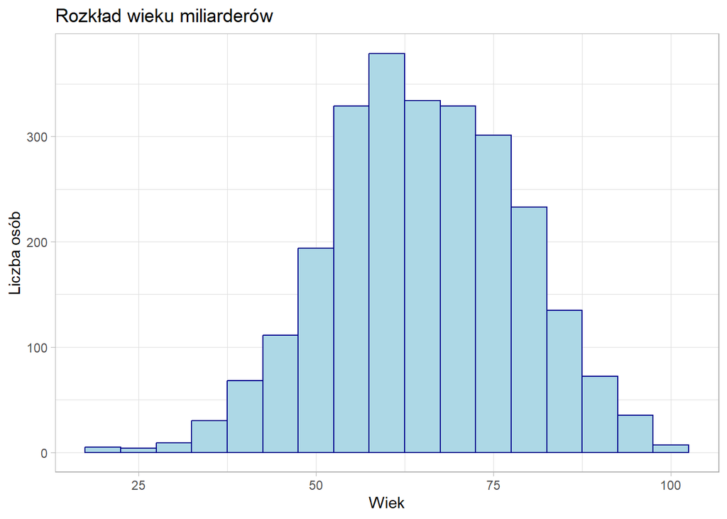

```r
dane %>%
  filter(!is.na(Age)) %>%
  ggplot() +
  geom_histogram(aes(x = Age), color = "darkblue", fill = "lightblue", binwidth = 5) +
  labs(title = "Rozkład wieku miliarderów", x = "Wiek", y = "Liczba osób") +
  theme_light()
```

```r
median(dane$Age, na.rm = TRUE)
```

```
## [1] 65
```

Tak jak można się było spodziewać, rozkład wieku jest mocno przesunięty w prawo. Mediana wynosi 65, co wskazuje na to że ponad połowa miliarderów przekroczyła wiek emerytalny w Polsce. Młodzi miliarderzy to niewielki ułamek całej populacji miliarderów.

Spójrzmy jeszcze na to jak wyglądają podstawowe statystyki opisowe dla poszczegółnych grup wiekowych, jeśli chodzi o zgromadzony majątek.

```r
dane %>%
  filter(!is.na(Age)) %>%
  mutate(AgeGroup = cut(Age, breaks = c(0,30,45,60,75,90,105))) %>%
  group_by(AgeGroup) %>%
  summarise(liczba = n(), srednia = mean(NetWorthMld),mediana = median(NetWorthMld), max = max(NetWorthMld), zmienno = round(sd(NetWorthMld)/mean(NetWorthMld), 2))
```

```
## # A tibble: 6 × 6
##   AgeGroup liczba srednia mediana   max zmienno
##   <fct>     <int>   <dbl>   <dbl> <dbl>   <dbl>
## 1 (0,30]       15    4.27    1.7   34.7    1.98
## 2 (30,45]     159    3.89    2     64.4    1.78
## 3 (45,60]     829    4.20    2.1  180      2.28
## 4 (60,75]     973    4.60    2.5  211      2.2
## 5 (75,90]     539    5.50    2.7  107      1.88
## 6 (90,105]     60    7.42    3.45 106      1.95
```

Warto zauważyć, że wszędzie średnia jest większa od mediany, co oznacza że rozkład jest prawostronnie skośny. Również wraz z wiekiem rośnie średnia i mediana majątku, co oznacza że po prostu z czasem miliarderzy gromadzą co raz większe majątki. Współczynnik zmienności w każdej z grup jest bardzo duży, co pokazuje nam, że w każdej z grup mamy miliarderów ze skrajnie dużym majątkiem jak i skrajnie małym, jeśli można mówić o małym majątku.

Dla pewności sprawdźmy jeszcze korelację między `Age`, a `NetWorthMld`.

### Czy wiek jest skorelowany z majątkiem?

Zaczniemy od korelacji Pearsona.

```r
cor(dane$Age, dane$NetWorthMld, use = "complete.obs")
```

```
## [1] 0.06705285
```

Korelacja Pearsona jest znikoma, bliska zeru. Sprawdzę jeszcze dla pewności korelację Spearmana, która jest odporna na wartości odstające, czyl te gigantyczne majątki niewiwielu.

```r
cor(dane$Age, dane$NetWorthMld, use = "complete.obs", method = "spearman")
```

```
## [1] 0.1440389
```

Nawet dla korelacji Spearmana ten wynik wskazują jedynie na bardzo słabą zależność, więc możemy stwierdzić że wiek nie jest wyznacznikiem zgromadzonych miliardów.

### Czy rozkład majątku różni się między kobietami a mężczyznami, czy kobiety mają zdecydowanie mniejszy majątek?

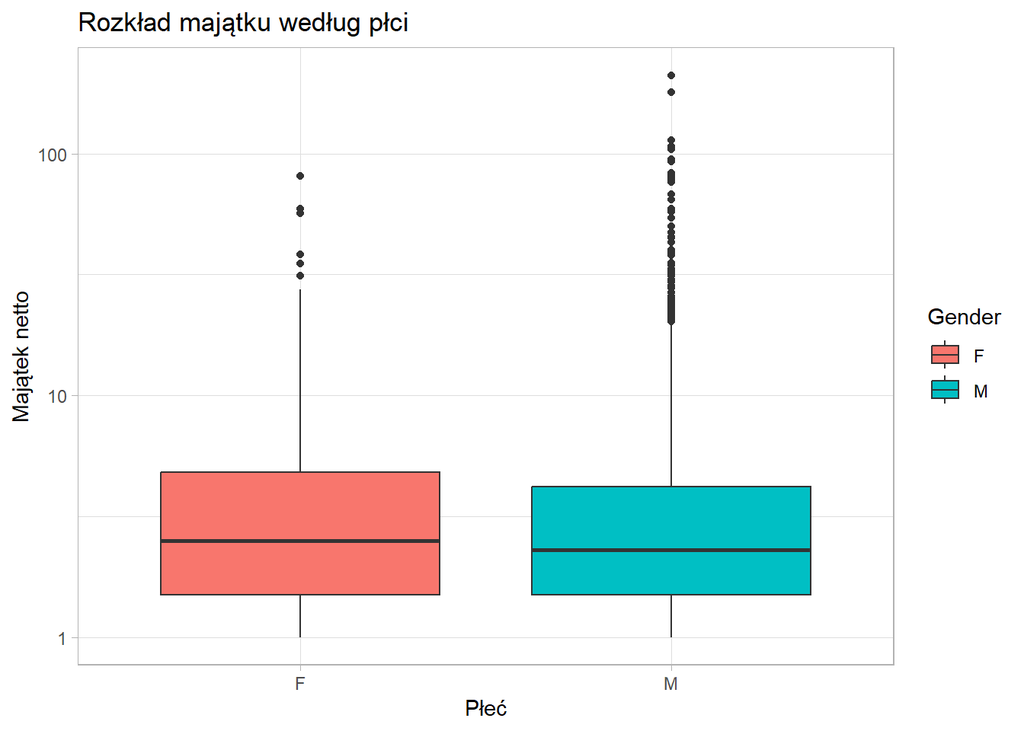

```r
dane %>%
  filter(!is.na(Gender)) %>%
  ggplot() +
  geom_boxplot(aes(x = Gender, y = NetWorthMld, fill = Gender)) +
  scale_y_log10() +
  labs(title = "Rozkład majątku według płci", x = "Płeć", y = "Majątek netto") +
  theme_light()
```

Po boxplotach można zauważyć, że mediany są bardzo zbliżone do siebie, co sugeruje że przeciętny miliarder, miliarderka posiada podobny majątek. Boxplot dla płci męskiej wyróżnia się dużo ilością wartości odstających, co jasno wskazuje na to że czołówka największyc miliarderów to głównie mężczyźni. Warto też zauważyć, że dla osi y użyłem skali logarytmicznej, bez niej pudełka byłyby bardzo płaskie, ledwo widoczne. Przy normalnej skali, wizualnie wartości odstające byłyby o wiele dalej od pudełek.

### Jak skumulowane są majątki miliarderów według krajów?

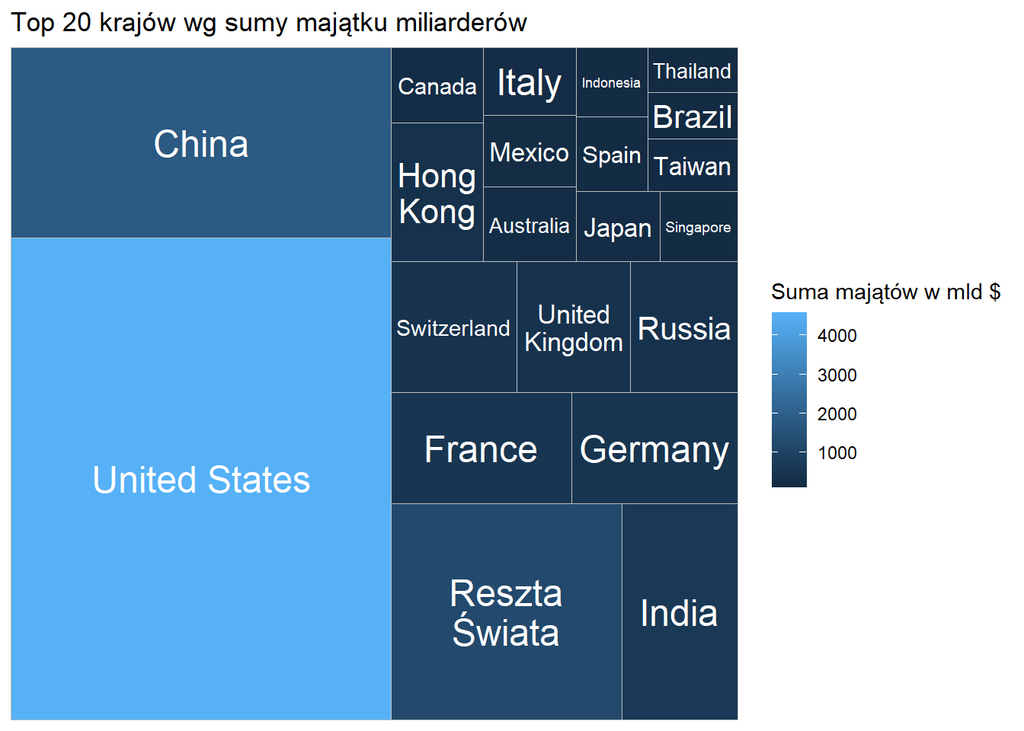

```r
dane %>%
  group_by(Country) %>%
  summarise(TotalNetWorth = sum(NetWorthMld, na.rm = TRUE)) %>%
  mutate(Ranking = row_number(desc(TotalNetWorth))) %>%
  mutate(CountryGroup = if_else(Ranking <= 20, Country, "Reszta Świata")) %>%
  group_by(CountryGroup) %>%
  summarise(TotalNetWorth = sum(TotalNetWorth)) %>%
  ggplot(aes(area = TotalNetWorth, fill = TotalNetWorth, label = CountryGroup)) +
  geom_treemap() +
  geom_treemap_text(colour = "white", place = "centre", reflow = TRUE) +
  labs(title = "Top 20 krajów wg sumy majątku miliarderów", fill = "Suma majątów w mld $")
```

### Skąd miliarderzy biorą swój majątek, ciężka praca czy odziedziczone bogactwo (według płci)?

Teraz sprawdzę, w jaki sposób miliarderzy nabyli swój majątek, czy jest on odziedziczony, a może to wynik ciężkiej pracy. Dodatkowo zobaczę, czy są jakieś istotne różnice ze względu na płeć.

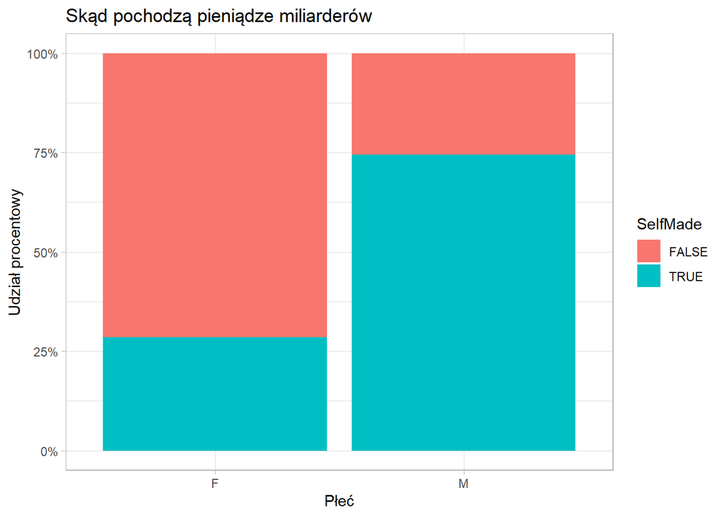

```r
dane %>%
  filter(!is.na(Gender) & !is.na(SelfMade)) %>%
  count(Gender, SelfMade) %>%
  group_by(Gender) %>%
  mutate(Percent = n / sum(n)) %>%
  ggplot(aes(x = Gender, y = Percent, fill = SelfMade)) +
  geom_col(position = "fill") +
  scale_y_continuous(labels = scales::percent) +
  labs(title = "Skąd pochodzą pieniądze miliarderów", x = "Płeć", y = "Udział procentowy") +
  theme_light()
```

Ku mojemu zdziwieniu aż 72% miliarderek odziedziczyło swój majątek, natomiast w przypadku mężczyzn jedynie co 4 mężczyzna. Możemy jeszcze sprawdzić jak wygląda to na poszczególnych kontynentach, ale już bez podziału na płeć.

### Czy źródła majątku różnią się, w zależności od kontynentu?

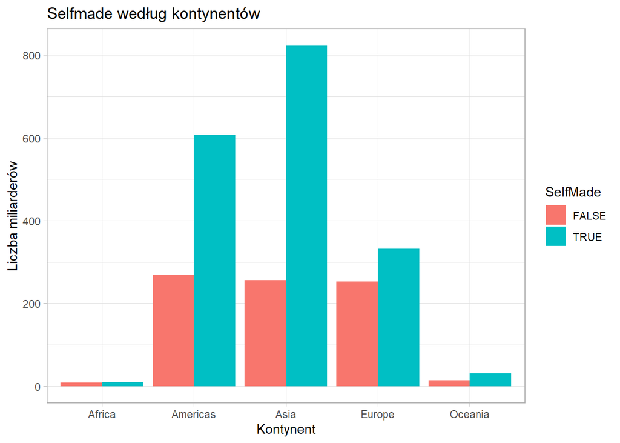

```r
dane %>%
  mutate(Continent = countrycode(sourcevar = Country, origin = "country.name", destination = "continent")) %>%
  filter(!is.na(Continent)) %>%
  ggplot(aes(x = Continent, fill = SelfMade)) +
  geom_bar(position = "dodge") +
  labs(title = "Selfmade według kontynentów", x = "Kontynent", y = "Liczba miliarderów", fill = "SelfMade") +
  theme_light()
```

Już na pierwszy rzut oka można zauważyć, że w Europie stosunek miliarderów którzy odziedziczyli swój majątek do tych, którzy na niego zapracowali jest dużo wyższy niż w obu Amerykach i Azji. Mimo, iż mówi się że kraje azjatyckie są biedniejsze to właśnie tam jest największa liczba miliarderów, którzy uzyskali go w wyniku ciężkiej pracy. Może to swiadczyć o dynamicznym rozwoju tego regionu. Teraz już, wiemy w jaki sposób miliarderzy zgromadzili swój majątek w poszczególnych kontynentach, warto teraz spojrzeć, czy poszczególne branże mają na to wpływ.

### Jaka branża wśród miliarderów jest najbardziej popularna, skąd biorą się ich majątki?

Zdecydowałem się wybrać tylko 15 największych branż pod względem liczby miliarderów.

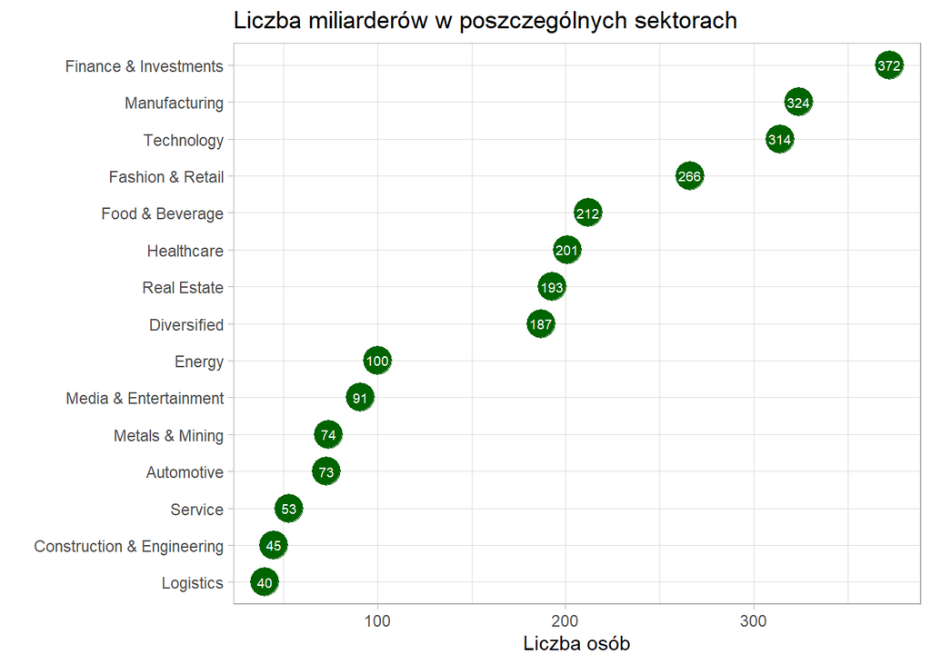

```r
dane %>%
  count(Category) %>%
  slice_max(n, n = 15) %>%
  ggplot(aes(x = n, y = reorder(Category, n))) +
  geom_point(size = 7, color = "darkgreen") +
  geom_text(aes(label = n), color = "white", size = 2.5) +
  labs(title = "Liczba miliarderów w poszczególnych sektorach", x = "Liczba osób",y = "") +
  theme_light()
```

Dla mnie ciekawą informacją jest to, że sektor `Finance & Investments` jest dominującym. Przy obecnym postępie technologicznym można było się spodziewać, że to branża `Technology` zdominuje. Choć oczywiście ten sektor nie wiele ustępuje sektorowi finansów. Ale tak naprawdę miliarderem można zostać w prawie każdej dziedzinie po spojrzeniu na wykres. Ciekawe czy sektor finansów dominuje tylko pod względem ilościowyma, a może też pod względem ilości zgromadzonego kapitału?

### Która branża przynosi największe zyski?

```r
dane %>%
  group_by(Category) %>%
  filter(n() > 20) %>%
  summarise(liczba = n(),srednia = mean(NetWorthMld),mediana = median(NetWorthMld), zmienno = sd(NetWorthMld)/mean(NetWorthMld)) %>%
  arrange(desc(srednia))
```

```
## # A tibble: 18 × 5
##    Category                   liczba srednia mediana zmienno
##    <chr>                       <int>   <dbl>   <dbl>   <dbl>
##  1 Automotive                     73    7.20    2.6    2.98
##  2 Telecom                        31    6.56    2.8    2.52
##  3 Fashion & Retail              266    6.39    2.5    2.57
##  4 Metals & Mining                74    6.04    2.6    1.21
##  5 Logistics                      40    5.99    3      1.44
##  6 Technology                    314    5.98    2.2    2.35
##  7 Diversified                   187    4.84    2.3    2.01
##  8 Gambling & Casinos             25    4.82    2.8    1.44
##  9 Media & Entertainment          91    4.70    2.5    2.39
## 10 Energy                        100    4.54    2.45   1.06
## 11 Food & Beverage               212    4.52    2.5    1.59
## 12 Finance & Investments         372    4.31    2.6    1.61
## 13 Sports                         39    3.45    2.1    0.882
## 14 Real Estate                   193    3.41    2.3    0.986
## 15 Service                        53    3.27    2.6    0.968
## 16 Healthcare                    201    3.2     2.1    1.02
## 17 Manufacturing                 324    3.15    2      1.10
## 18 Construction & Engineering     45    2.63    2.1    0.826
```

Choć sektor finansów zajmował pierwsze miejsce pod względem ilości miliarderów, to pod względem średniej wielkości majątku zajmuje on dopiero 12 miejsce, więc można powiedzieć że to taka fabryka małych miliarderów. Na pierwszym miejscu znowu się spodziewałem branży technologicznej, a jednak to motoryzacyjna uplasowała się na szczycie. Jednak warto zauważyć, że do sektoru `Automotive` został zaliczony na przykład Elon Musk. Widać to po współczynniku zmienności, który w tej branży jest najwyższy.

# Podsumowanie

Wiek nie jest skorelowany z posiadanym majątkiem, nie ma znaczenia jak długo gromadzimy pieniądze. USA oraz Chiny posiadają miliarderów o największym skumulowanym kapitale, na oko odczytując z wykresu jest to połowa majątku miliarderów z całego świata.

Jeśli chodzi o płeć to znacząco różni się pochodzenie kapitału, zdecydowana większość miliarderek dziedziczy swój majątek, a u mężczyzn wręcz przeciwnie bo zdecydowana mniejszość. Networth obu tych grup dla jednej osoby jest podobny, choć do mężczyźni mają więcej przypadków odstających w pozytywnym znaczeniu.

I na koniec branża, choć to sektor finansów okazał się najbardziej popularny/liczny wśród miliarderów to jednak średnio więcej zarabia się w branży motoryzacyjnej.